# 一、Introduction

Copyright by 常老师 & 土豆

Datetime: 2017-12-19

## 可视化的目的：解释数据 + 传递信息

- 比较两组数据的大小 （可以很直观的做比较，可视化建立起数据和人之间的桥梁）
- 校验两组数据的差异 （比如看两组数据是否来自同一个分布，数据可视化可以帮到你！）
- 统计随机变量的分布 （如分位数、3$\sigma$区间等统计量的可视化，可以不言自明的获得信息！）
- and so on

## 可视化的原则：**Simpler is almost always better!**

高效的表达 = 清晰的思路 = 有价值的工作

- 尽量用低维度表达
- 一定避免视觉噪声（标记、注释、颜色） 切忌喧宾夺主～
- 确保各个元素清晰

## 可视化的模式

### 交互式 （下一讲）

- 用于引导／发现
- 服务于个体

### 呈现式 （本次讲）

- 用于展示讲述
- 服务于群体

### 交互呈现式

| 分类 | 用户交互 | 图像生成 | 目标受众 | 传媒媒介 |
| --- | --- | --- | --- | --- |
| 交互式 | 用户完全掌控数据 | 实时 | 少量个体 | 网络交互软件 |
| 交互呈现式 | 用户部分掌控数据 | 实时 | 少量群体 | 网络自助设备 |
| 呈现式 | 用户不能掌控数据 | 预先 | 大量群体 | 视频演示文稿 |

## 可视化的对象 （也就是数据）

|  | 离散数据 | 连续数据 |
| --- | --- | --- |
| 有序数据 | 尺码、自然数 | 温度、经纬度 |
| 无序数据 | 形状、类别 | 方向、色彩 |

三类数据：定量数据、定序数据、定类数据

- 定量数据（Quantitative）：连续、离散
- 定序数据（Ordinal）：尺码、态度
- 定类数据（Categorical）：城市、品类

## 可视化 VS 翻译

> 译事三难，**信，达，雅**。
- 信：准确
- 达：明白
- 雅：审美

  这是值得追求的数据可视化的三个层面！

### 定量数据

- 位置 > 长度/角度 > 面积 > 体积 > 密度 > 颜色

上述为优选关系，体现了低维度优选的原则。

### 定序数据

- 位置 > 密度 > 颜色 > 连接 > 包含

其中的密度可以通过疏密程度来体现；颜色主要是通过深浅体现；连接可以用镜头等从属关系来体现有序性。

### 定类数据

- 位置 > 颜色 > 连接 > 包含 > 形状

表现类之间的关系。

- **土豆小窍门**:

  面对某一列的特征, 心中首先要掂量一下: 离散的? 连续的?

  之后再掂量是不是定序的?

## 可视化工具包

- matplotlib：满足基本需求 （用的好可以满足所有的需求，就是用起来太麻烦）
- seaborn：满足颜控需求 （非常漂亮！非常容易！）
- bokeh：满足交互需求 （交互式的啦！）

## 可能涉及到的内容

- 数据可视化的基本处理流程
- 数据分析及其可视化的选择
- 数据可视化结果的分析解读
- 数据可视化的一些实际案例

## 学员的期望收获

- level1：有**强烈的**用可视化技术去呈现分析结果的**欲望**
- level2：针对具体的问题能够**快速确定**可视化实施**方案**
- level3：养成一种能**用图说清楚**的事绝不用文字的习惯
- level4：有意识地**提升**可视化结果的**审美和自解释属性**

## 本讲是什么? 不是什么?

- 不会完整涉及工具包的所有api等使用方法, 不会谈过于细节的数学原理和统计理由, 不是完备的可以一劳永逸的可视化思考.
- 听后在需要做可视化的时候, 能够有想法, 有思路, 高效的画出脑中所想画的图.
- 穿插的内容可能会涉及python基础, 数据清理和特征工程等知识.

## tips

- 希望每位学员能够根据自身需求列出一个基本操作清单
- 希望每位学员能够结合自身业务列出一个方法论的指南
- 认真敲一遍所有的代码, 更重要的是, 完成练习题! 熟悉刚刚所学的!

# 二、数据可视化的主要步骤

- 数据准备
- 确定图表
- 分析迭代
- 输出结论

## 步骤一：数据准备

- 数据规模：数据分组、数据采样  
  (处理大数据时尤为需要）
- 数据类型：数值数据、分类数据  
  (一定要特别清楚是什么类型的数据， 数值？还是分类？）
- 数据异常：取值异常、数据缺失

```python
import numpy as np
import pandas as pd
import scipy as sp
```

### 1. 数据分组

- `groupby`

```python
df = pd.DataFrame({'key1' : ['a','a','b','b','a'],
                'key2' : ['one','two','one','two','one'],
                'data1' : np.random.normal(size=5),
                'data2' : np.random.normal(size=5)})
df
```

|  | data1 | data2 | key1 | key2 |
| --- | --- | --- | --- | --- |
| 0 | 0.377590 | 0.092903 | a | one |
| 1 | 0.357242 | -0.209132 | a | two |
| 2 | 0.343728 | 1.618713 | b | one |
| 3 | 0.099069 | -0.171869 | b | two |
| 4 | -0.351848 | -1.280469 | a | one |

```python
df['data1'].groupby(df['key1']).mean()
```

```
key1
a    0.127661
b    0.221398
Name: data1, dtype: float64
```

### 2. 数据采样

- `sample`

```python
import random
x = np.arange(0,100)
y = random.sample(list(x),10)
y
```

```
[94, 96, 59, 30, 74, 51, 9, 11, 86, 46]
```

### 3. 取值异常

#### 去掉异常

```python
x = np.arange(0,100)
y = x[(x>90)|(x<10)]
y
```

```
array([ 0,  1,  2,  3,  4,  5,  6,  7,  8,  9, 91, 92, 93, 94, 95, 96, 97,
       98, 99])
```

#### 替换异常

```python
y = x
for i in np.arange(0,100):
    if i >= 10 and i <= 90:
        y[i] = 0
    else:
        y[i] = i
y
```

```
array([ 0,  1,  2,  3,  4,  5,  6,  7,  8,  9,  0,  0,  0,  0,  0,  0,  0,
        0,  0,  0,  0,  0,  0,  0,  0,  0,  0,  0,  0,  0,  0,  0,  0,  0,
        0,  0,  0,  0,  0,  0,  0,  0,  0,  0,  0,  0,  0,  0,  0,  0,  0,
        0,  0,  0,  0,  0,  0,  0,  0,  0,  0,  0,  0,  0,  0,  0,  0,  0,
        0,  0,  0,  0,  0,  0,  0,  0,  0,  0,  0,  0,  0,  0,  0,  0,  0,
        0,  0,  0,  0,  0,  0, 91, 92, 93, 94, 95, 96, 97, 98, 99])
```

#### NA处理

- `dropna`
- `fillna`

```python
from numpy import nan
data = pd.Series([1,nan,2,nan,3,nan])
data
```

```
0    1.0
1    NaN
2    2.0
3    NaN
4    3.0
5    NaN
dtype: float64
```

```python
data.dropna()
```

```
0    1.0
2    2.0
4    3.0
dtype: float64
```

```python
data.fillna(0)
```

```
0    1.0
1    0.0
2    2.0
3    0.0
4    3.0
5    0.0
dtype: float64
```

## 步骤二：确定图表

数据可视化里通常面临的三类问题：

- **关联**分析：散点图，曲线图(scatter, plot)
- **分布**分析：灰度图，密度图(hist, gaussian_kde, plot）
- **分类**分析：柱状图，箱式图(bar, boxplot)

## 步骤三：分析迭代

- 确定拟合模型：OLS, fit OLS = 最小二乘；fit = 拟合
- 分析拟合性能：summary_table 统计学汇总
- 确定数据分布：hist
- 确定重点区间：quartile 分布的上下四分位数，以及各分位数之间的区间

# 三、Matplotlib —— 基本操作

## 常用设置

- 获得当前图表对象 `fig = matplotlib.pyplot.gcf()`

  (gcf = get current figure)
- 常用图表对象设置

  例子：两种设置图像大小的方式，但是有区别！

  `fig.set_size_inches(10,10) # 以英尺为单位`

  `matplotlib.pyplot.figure(figsize=(14,7))`
- 保存当前图表对象 `matplotlib.pyplot.savefig("figure1.png")`

```python
import matplotlib
from matplotlib import pyplot as plt  # 简写 matplotlib.pyplot 为 plt
import numpy as np
import scipy
# 包含不同的pdf
from scipy import stats
# 让图片显示在notebook中
%matplotlib inline

# plt.show(), plt.cla(), plt.clf(), plt.close()
```

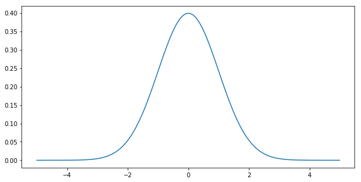

```python
plt.figure(figsize=(10,5))      # 先生成一个10*5的图
x = np.arange(-5,5,0.01)        # 生成数字序列
y = stats.norm.pdf(x,0,1)       # loc = mean, scale = sigma 用统计学包输出均值为0，方差为1的正态分布
plt.plot(x,y)                   # 画图！
plt.savefig("figure1.png")      # 把图保存为figure1（不支持jpg）
```

```python
plt.figure(figsize=(5,5))       # 关键：.figure 函数会清空画面
plt.savefig("figure2.png")      # 为什么figure2是空的？因为还没有画，画面成了空白的方形图。
```

```python
fig = plt.gcf()
fig.set_size_inches(5,8)
plt.savefig("figure3.png")      # 为什么figure3是空的？因为gcf取得的是上一个空白图哦～
```

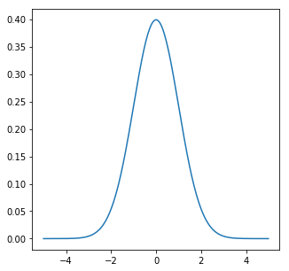

```python
plt.plot(x,y)
fig = plt.gcf()
fig.set_size_inches(5,5)
plt.savefig("figure4.png")      # figure4图片终于是5*5的正方形
```

两种设置图像大小的方法如何选择？画之前设置 VS 画之后设置~

`.figure` 是一定要画之前就设置好，一旦画过了之后再想做局部的修改，就只能用当前句柄对象`.set_*`的方式设置了图像了。（所谓的句柄，就是类似指针的指针！）

## 常用图形

- 曲线图：`matplotlib.pyplot.plot(data)`
- 灰度图：`matplotlib.pyplot.hist(data)`
- 散点图：`matplotlib.pyplot.scatter(data)`
- 箱式图：`matplotlib.pyplot.boxplot(data)`

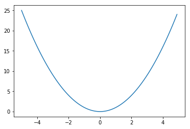

```python
x = np.arange(-5,5,0.1) # -5到5区间，相隔0.1取点为list
y = x ** 2
plt.plot(x,y)
# 曲线图演示
```

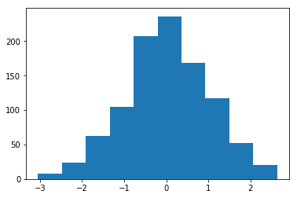

```python
x = np.random.normal(size=1000) # 随机生成正态分布的1000个样本
plt.hist(x, bins=10)
# 灰度图histogram，其中bins是柱子的数目
```

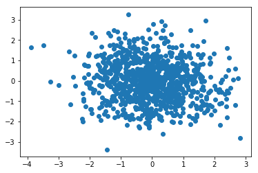

```python
x = np.random.normal(size=1000)
y = np.random.normal(size=1000)
plt.scatter(x,y)
# 散点图
```

[output not shown]

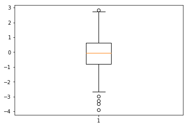

```python
plt.boxplot(x)
# 箱式图  （正态分布）
```

### 箱式图科普

（信息含量很大～有一半的数值都在箱子里面）

- 上边缘（Q3+1.5IQR）、下边缘（Q1-1.5IQR）（其中 IQR=Q3-Q1 是 interquartile range）

  <注：均值是所有数据的平均值，受异常值影响！>
- 异常值（上下边缘以外的点被定义为异常值，算是异常值的阈值）
  - 处理异常值时与$3\sigma$标准的异同：统计边界是否受异常值影响、容忍度的大小

btw：$\sigma \Rightarrow 68.2\%$，$2\sigma \Rightarrow 95.4\%$，$3\sigma \Rightarrow 99.7\%$

$3\sigma$标准以均值和方差作为度量，异常值对其的影响是非常大的。若按照分位数刻画的箱式图来考察的话，只要异常值不影响排序，那么异常值的大小是怎样都是什么关系的，但对于$3\sigma$标准来说，不管异常值是否影响排序，其值的任何变化都会显著影响方差$\sigma$。

所以，如果能估计出数据存在特别特别离谱的异常值时，建议可以通过箱式图来考察，去度量数据的统计特性、集中程度、分布情况等；若数据中没有太可能有太多异常值的时候，就可以用$3\sigma$标准来考察。

- 例子：
  - 箱子很短，说明数据很集中；箱子很长，说明数据很分散；虚线很长，说明异常值不仅大，还非常多。所以，如果想截取一个干净的数据，就需要把分位数的上下阈值定的足够的窄才行。

## 常用样式

### 颜色/线型/标记

- `pyplot.plot(x, color='g')` 颜色
- `pyplot.plot(x, linestyle='—')` 线形
- `pyplot.plot(x, marker='+')` 曲线上的点
- `pyplot.plot(x, 'ro-')`

### 标题

- `pyplot.title("xxxx")`

### 坐标轴标签

- `pyplot.xlabel("xxxx")`
- `pyplot.ylabel("xxxx")`

### 图注

- `pyplot.legend(loc="best")`

配合

- `pyplot.plot(label="xxxx")`

### 网格

- `pyplot.grid(color="xxx", linestyle="-", alpha=0.5)`

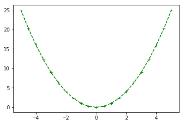

```python
x = np.arange(-5,5.5,0.5)
y = x ** 2
plt.plot(x,y,color='g',linestyle='--',marker='+')
# 颜色/线型/标记
```

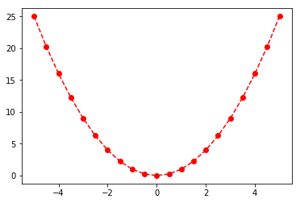

```python
plt.plot(x,y,'ro--') # 可以合在一起写
```

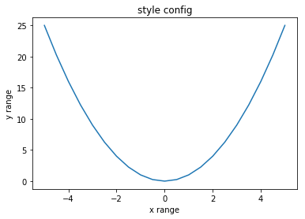

```python
plt.title("style config")   # 标题
plt.xlabel("x range")       # 横坐标
plt.ylabel("y range")       # 纵坐标
plt.plot(x,y)
```

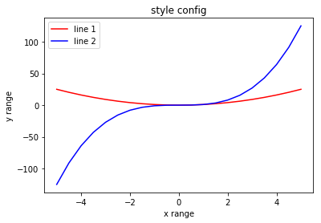

```python
y1 = x ** 2
y2 = x ** 3
plt.plot(x,y1,'r-',label='line 1')
plt.plot(x,y2,'b-',label='line 2')
plt.title("style config")
plt.xlabel("x range")
plt.ylabel("y range")
plt.legend(loc="best")
```

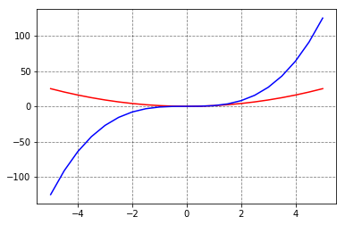

```python
plt.plot(x,y1,'r')
plt.plot(x,y2,'b')
plt.grid(color='k',linestyle='--',alpha=0.5)   # 设置网格 alpha参数表示透明度(%)
```

# 四、Matplotlib — 案例：华盛顿自行车租赁情况分析

## 步骤1：确认数据

```python
import pandas as pd # 读取数据到DataFrame
import urllib # 获取网络数据
import tempfile # 创建临时文件系统
import shutil # 文件操作
import zipfile # 压缩解压


temp_dir = tempfile.mkdtemp() # 建立临时目录
data_source = 'http://archive.ics.uci.edu/ml/machine-learning-databases/00275/Bike-Sharing-Dataset.zip' # 网络数据地址
zipname = temp_dir + '/Bike-Sharing-Dataset.zip' # 拼接文件和路径
try:
    urllib.urlretrieve(data_source, zipname) # 获得数据 python2.x
except:
    urllib.request.urlretrieve(data_source, zipname) # 获得数据  python3.x
zip_ref = zipfile.ZipFile(zipname, 'r') # 创建一个ZipFile对象处理压缩文件
zip_ref.extractall(temp_dir) # 解压
zip_ref.close()

daily_path = temp_dir + '/day.csv'
daily_data = pd.read_csv(daily_path) # 读取csv文件
daily_data['dteday'] = pd.to_datetime(daily_data['dteday']) # 把字符串数据传换成日期数据
drop_list = ['instant', 'season', 'yr', 'mnth', 'holiday', 'workingday', 'weathersit', 'atemp', 'hum'] # 不关注的列
daily_data.drop(drop_list, inplace = True, axis = 1) # inplace=true在对象上直接操作

shutil.rmtree(temp_dir) # 删除临时文件目录

daily_data.head() # 看一看数据哈~
```

|  | dteday | weekday | temp | windspeed | casual | registered | cnt |
| --- | --- | --- | --- | --- | --- | --- | --- |
| 0 | 2011-01-01 | 6 | 0.344167 | 0.160446 | 331 | 654 | 985 |
| 1 | 2011-01-02 | 0 | 0.363478 | 0.248539 | 131 | 670 | 801 |
| 2 | 2011-01-03 | 1 | 0.196364 | 0.248309 | 120 | 1229 | 1349 |
| 3 | 2011-01-04 | 2 | 0.200000 | 0.160296 | 108 | 1454 | 1562 |
| 4 | 2011-01-05 | 3 | 0.226957 | 0.186900 | 82 | 1518 | 1600 |

## 步骤2：配置参数

```python
# 引入3.x版本的除法和打印
from __future__ import division, print_function
from matplotlib import pyplot as plt
import pandas as pd
import numpy as np
# 在notebook中显示绘图结果
%matplotlib inline
```

```python
# 设置一些全局的资源参数，可以进行个性化修改
import matplotlib
# 设置图片尺寸 14" x 7"
# rc: resource configuration
matplotlib.rc('figure', figsize = (14, 7))
# 设置字体 14
matplotlib.rc('font', size = 14)
# 不显示网格
matplotlib.rc('axes', grid = False)
# 设置背景颜色是白色
matplotlib.rc('axes', facecolor = 'white')
```

## 步骤3：关联分析

**关联分析是所有分析中的第一步！考虑的两组数据之间是否存在关系～**

### 散点图

- 分析变量关系

  判断：“正相关”？“负相关”？还是“不相关”？

```python
# 包装一个散点图的函数便于复用
def scatterplot(x_data, y_data, x_label, y_label, title):

    # 创建一个绘图对象
    fig, ax = plt.subplots()
    # 调用plt句柄画一个图，返回两个变量fig，ax，分别是figure和axis的缩写。函数返回一个figure图像和一个子图ax的array列表。
    # 一个fig图里边会套好几个ax，而每个ax会负责当前坐标上的图。所以任何绘制的图形都是在ax上完成的；
    # 而设置整个画布，将是在fig上完成。

    # 不显示顶部和右侧的坐标线
    ax.spines['top'].set_color('none')
    ax.spines['right'].set_color('none')
    # 设置数据x_data和y_data、点的大小s、点的颜色color和透明度alpha
    ax.scatter(x_data, y_data, s = 10, color = '#539caf', alpha = 0.75)

    # 添加标题和坐标说明
    ax.set_title(title)
    ax.set_xlabel(x_label)
    ax.set_ylabel(y_label)
```

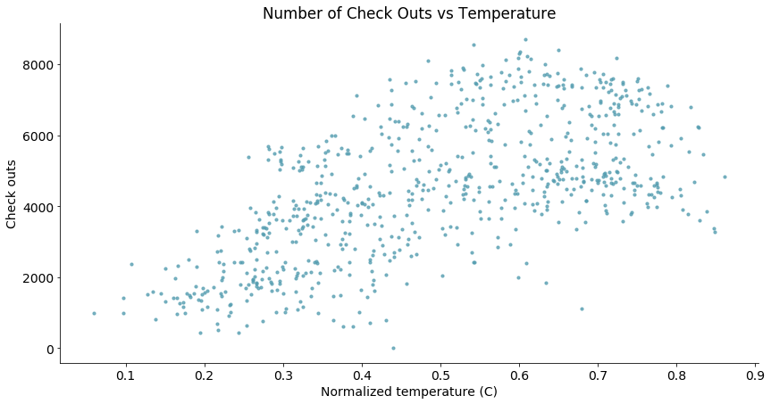

```python
# 绘制散点图
scatterplot(x_data = daily_data['temp']
            , y_data = daily_data['cnt']
            , x_label = 'Normalized temperature (C)'
            , y_label = 'Check outs'
            , title = 'Number of Check Outs vs Temperature')
```

### 曲线图

- 拟合变量关系（绘制拟合关联曲线）

```python
# 线性回归
import statsmodels.api as sm
from statsmodels.stats.outliers_influence import summary_table
x = sm.add_constant(daily_data['temp']) # 线性回归增加常数项
y = daily_data['cnt']
regr = sm.OLS(y, x) # 普通最小二乘模型，ordinary least square model
res = regr.fit()
# 从模型获得拟合数据
st, data, ss2 = summary_table(res, alpha=0.05) # 置信水平alpha=5%，st数据汇总，data数据详情，ss2数据列名
fitted_values = data[:,2]
```

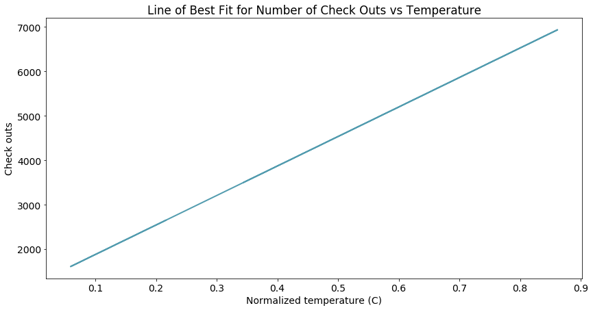

```python
# 包装曲线绘制函数
def lineplot(x_data, y_data, x_label, y_label, title):
    # 创建绘图对象
    _, ax = plt.subplots()

    # 绘制拟合曲线，lw=linewidth，alpha=transparancy
    ax.plot(x_data, y_data, lw = 2, color = '#539caf', alpha = 1)

    # 添加标题和坐标说明
    ax.set_title(title)
    ax.set_xlabel(x_label)
    ax.set_ylabel(y_label)

# 调用绘图函数
lineplot(x_data = daily_data['temp']
         , y_data = fitted_values
         , x_label = 'Normalized temperature (C)'
         , y_label = 'Check outs'
         , title = 'Line of Best Fit for Number of Check Outs vs Temperature')
```

```python
x.head()
type(regr)	# 普通最小二乘模型
st			# 数据汇总
```

[output not shown]

### 带置信区间的曲线图

- 评估曲线拟合结果（对曲线图的进一步分析～）

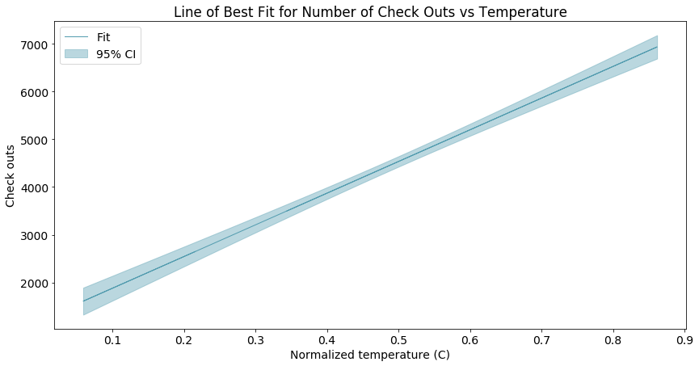

```python
# 获得5%置信区间的上下界
predict_mean_ci_low, predict_mean_ci_upp = data[:,4:6].T

# 创建置信区间DataFrame，上下界
CI_df = pd.DataFrame(columns = ['x_data', 'low_CI', 'upper_CI'])
CI_df['x_data'] = daily_data['temp']
CI_df['low_CI'] = predict_mean_ci_low
CI_df['upper_CI'] = predict_mean_ci_upp
CI_df.sort_values('x_data', inplace = True) # 根据x_data进行排序

# 绘制置信区间
def lineplotCI(x_data, y_data, sorted_x, low_CI, upper_CI, x_label, y_label, title):
    # 创建绘图对象
    _, ax = plt.subplots()

    # 绘制预测曲线
    ax.plot(x_data, y_data, lw = 1, color = '#539caf', alpha = 1, label = 'Fit')
    # 绘制置信区间，顺序填充
    ax.fill_between(sorted_x, low_CI, upper_CI, color = '#539caf', alpha = 0.4, label = '95% CI')
    # 添加标题和坐标说明
    ax.set_title(title)
    ax.set_xlabel(x_label)
    ax.set_ylabel(y_label)

    # 显示图例，配合label参数，loc=“best”自适应方式
    ax.legend(loc = 'best')

# Call the function to create plot
lineplotCI(x_data = daily_data['temp']
           , y_data = fitted_values
           , sorted_x = CI_df['x_data']
           , low_CI = CI_df['low_CI']
           , upper_CI = CI_df['upper_CI']
           , x_label = 'Normalized temperature (C)'
           , y_label = 'Check outs'
           , title = 'Line of Best Fit for Number of Check Outs vs Temperature')
```

### 双坐标曲线图

- 曲线拟合不满足置信阈值时，考虑增加独立变量
- 分析不同尺度多变量的关系

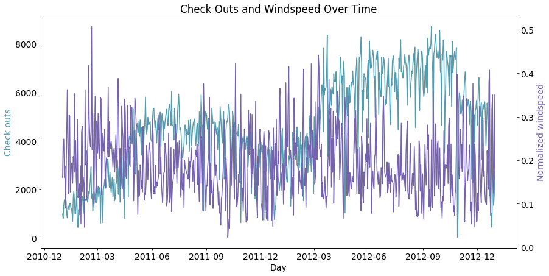

```python
# 双纵坐标绘图函数
def lineplot2y(x_data, x_label, y1_data, y1_color, y1_label, y2_data, y2_color, y2_label, title):
    _, ax1 = plt.subplots()
    ax1.plot(x_data, y1_data, color = y1_color)
    # 添加标题和坐标说明
    ax1.set_ylabel(y1_label, color = y1_color)
    ax1.set_xlabel(x_label)
    ax1.set_title(title)

    ax2 = ax1.twinx() # 两个绘图对象共享横坐标轴（关键！）
    ax2.plot(x_data, y2_data, color = y2_color)
    ax2.set_ylabel(y2_label, color = y2_color)
    # 右侧坐标轴可见
    ax2.spines['right'].set_visible(True)

# 调用绘图函数
lineplot2y(x_data = daily_data['dteday']
           , x_label = 'Day'
           , y1_data = daily_data['cnt']
           , y1_color = '#539caf'
           , y1_label = 'Check outs'
           , y2_data = daily_data['windspeed']
           , y2_color = '#7663b0'
           , y2_label = 'Normalized windspeed'
           , title = 'Check Outs and Windspeed Over Time')
```

从图中可以察觉到**总租车量**与**风速**的大小存在**负相关性**。

## 步骤4：分布分析

上一步是知道了变量之间的关系，接下来需要进一步知晓变量服从什么样的分布。因为分布情况会决定我们后续的处理方式。

### 灰度图（粗略）

- 粗略区间计数

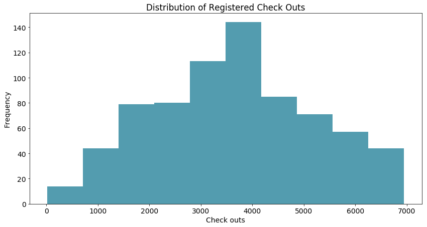

```python
# 绘制灰度图的函数
def histogram(data, x_label, y_label, title):
    _, ax = plt.subplots()
    res = ax.hist(data, color = '#539caf', bins=10) # 设置bin的数量
    ax.set_ylabel(y_label)
    ax.set_xlabel(x_label)
    ax.set_title(title)
    return res

# 绘图函数调用
res = histogram(data = daily_data['registered']
           , x_label = 'Check outs'
           , y_label = 'Frequency'
           , title = 'Distribution of Registered Check Outs')
```

```python
res[0] # value of bins
```

```
array([  14.,   44.,   79.,   80.,  113.,  144.,   85.,   71.,   57.,   44.])
```

```python
res[1] # boundary of bins
```

```
array([   20. ,   712.6,  1405.2,  2097.8,  2790.4,  3483. ,  4175.6,
        4868.2,  5560.8,  6253.4,  6946. ])
```

可以猜一下大概的分布，比如上面的图可能是正态分布。

### 堆叠直方图（粗略）

- 比较两个分布

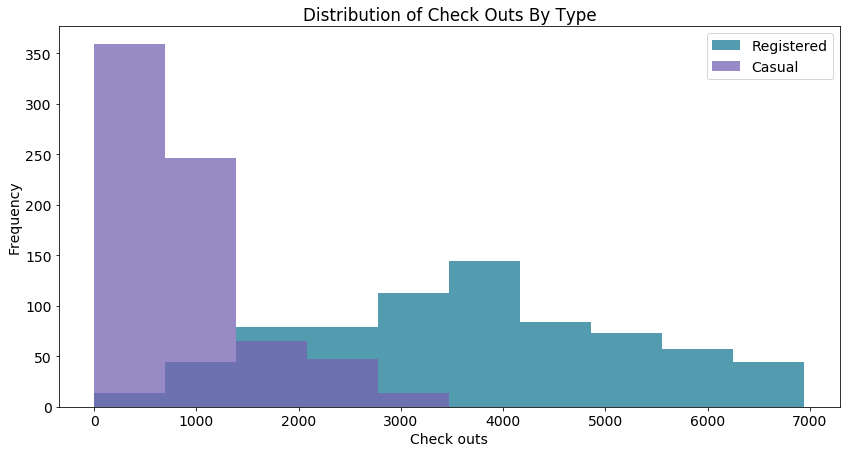

```python
# 绘制堆叠的直方图
def overlaid_histogram(data1, data1_name, data1_color, data2, data2_name, data2_color, x_label, y_label, title):
    # 归一化数据区间，对齐两个直方图的bins
    max_nbins = 10
    data_range = [min(min(data1), min(data2)), max(max(data1), max(data2))]
    binwidth = (data_range[1] - data_range[0]) / max_nbins
    bins = np.arange(data_range[0], data_range[1] + binwidth, binwidth) # 生成直方图bins区间

    # Create the plot
    _, ax = plt.subplots()
    ax.hist(data1, bins = bins, color = data1_color, alpha = 1, label = data1_name)
    ax.hist(data2, bins = bins, color = data2_color, alpha = 0.75, label = data2_name)
    ax.set_ylabel(y_label)
    ax.set_xlabel(x_label)
    ax.set_title(title)
    ax.legend(loc = 'best')

# Call the function to create plot
overlaid_histogram(data1 = daily_data['registered']
                   , data1_name = 'Registered'
                   , data1_color = '#539caf'
                   , data2 = daily_data['casual']
                   , data2_name = 'Casual'
                   , data2_color = '#7663b0'
                   , x_label = 'Check outs'
                   , y_label = 'Frequency'
                   , title = 'Distribution of Check Outs By Type')
```

- 关于上图：
  - registered：注册预约过的人的分布（绿色），正态分布，why
    - 预约租车的人都是有计划性的，一般都是正态分布，呈现出大部分人在某区间内选择的现象。
  - casual：偶然来租车的人的分布（紫色），疑似指数分布，why
    - 偶然来租车的人是有随机性的～（我个人觉得可以看作是半个正态分布，表示大部分偶然租车的人，是倾向于选择少租 ）

不过总感觉灰度图太糙了，有没有~肿么破~

### 密度图（精细）

- 精细刻画概率分布

KDE: **kernal density estimate** 核密度估计 $$ \hat{f}_h(x) = \frac{1}{n}\sum\limits_{i=1}^n K_h(x-x_i) = \frac{1}{nh}\sum\limits_{i=1}^n K(\frac{x-x_i}{h}) $$

用核函数去顾及每个采样点，最终把他们做一个平均（[REF](https://en.wikipedia.org/wiki/Kernel_density_estimation)）。

```python
# 计算概率密度
from scipy.stats import gaussian_kde
data = daily_data['registered']
density_est = gaussian_kde(data) # kernal density estimate: https://en.wikipedia.org/wiki/Kernel_density_estimation
# 控制平滑程度，数值越大，越平滑哈
density_est.covariance_factor = lambda : .3
# 这个数字越大，平滑度越好，但细节不足；数字越小，细节很突兀，
# 看不清分布趋势了。
# 该算法其实就是用正态分布去拟合的，用多个正态分布线性叠加，
# 叠加后也会是正态分布，但是叠加前被拟合的分布未必正态分布。
density_est._compute_covariance()
x_data = np.arange(min(data), max(data), 200)
```

```python
# 绘制密度估计曲线
def densityplot(x_data, density_est, x_label, y_label, title):
    _, ax = plt.subplots()
    ax.plot(x_data, density_est(x_data), color = '#539caf', lw = 2)
    ax.set_ylabel(y_label)
    ax.set_xlabel(x_label)
    ax.set_title(title)
```

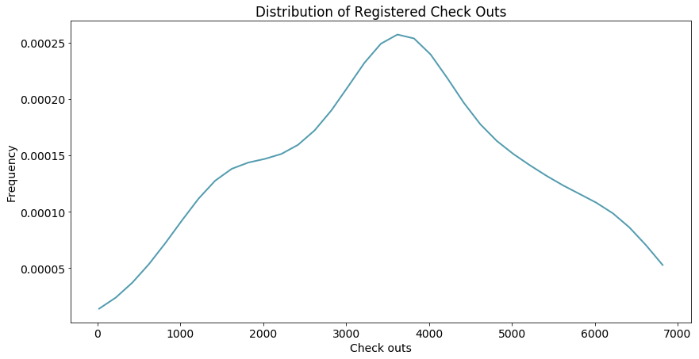

```python
# 调用绘图函数
densityplot(x_data = x_data
            , density_est = density_est
            , x_label = 'Check outs'
            , y_label = 'Frequency'
            , title = 'Distribution of Registered Check Outs')
```

```python
type(density_est)
```

```
scipy.stats.kde.gaussian_kde
```

或许我们可以堆叠多个直方图来分析分布～

## 步骤5：组间分析

- 组间定量比较
- 分组粒度
- 组间聚类

### 柱状图

- 一级类间均值方差比较

```python
# 分天分析统计特征
mean_total_co_day = daily_data[['weekday', 'cnt']].groupby('weekday').agg([np.mean, np.std])
mean_total_co_day.columns = mean_total_co_day.columns.droplevel()

# 定义绘制柱状图的函数
def barplot(x_data, y_data, error_data, x_label, y_label, title):
    _, ax = plt.subplots()
    # 柱状图（注：x_data是不能接受str或者float的）
    ax.bar(x_data, y_data, color = '#539caf', align = 'center')
    # 绘制方差
    # ls='none'去掉bar之间的连线
    ax.errorbar(x_data, y_data, yerr = error_data, color = '#297083', ls = 'none', lw = 5)	# lw线宽
    ax.set_ylabel(y_label)
    ax.set_xlabel(x_label)
    ax.set_title(title)
```

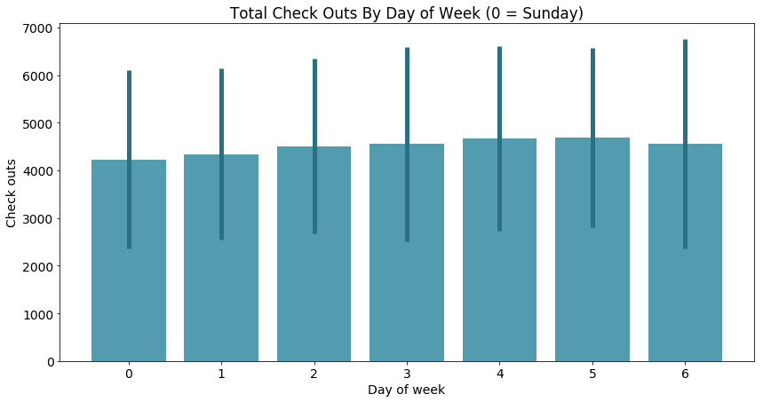

```python
# 绘图函数调用
barplot(x_data = mean_total_co_day.index.values
        , y_data = mean_total_co_day['mean']           # 取每天租车量的均值
        , error_data = mean_total_co_day['std']
        , x_label = 'Day of week'
        , y_label = 'Check outs'
        , title = 'Total Check Outs By Day of Week (0 = Sunday)')
```

```python
mean_total_co_day.columns
daily_data[['weekday', 'cnt']].groupby('weekday').agg([np.mean, np.std])
```

| weekday | cnt mean | cnt std |
| --- | --- | --- |
| 0 | 4228.828571 | 1872.496629 |
| 1 | 4338.123810 | 1793.074013 |
| 2 | 4510.663462 | 1826.911642 |
| 3 | 4548.538462 | 2038.095884 |
| 4 | 4667.259615 | 1939.433317 |
| 5 | 4690.288462 | 1874.624870 |
| 6 | 4550.542857 | 2196.693009 |

### 堆积柱状图

- 多级类间相对占比比较

```python
mean_by_reg_co_day = daily_data[['weekday', 'registered', 'casual']].groupby('weekday').mean()
mean_by_reg_co_day
```

| weekday | registered | casual |
| --- | --- | --- |
| 0 | 2890.533333 | 1338.295238 |
| 1 | 3663.990476 | 674.133333 |
| 2 | 3954.480769 | 556.182692 |
| 3 | 3997.394231 | 551.144231 |
| 4 | 4076.298077 | 590.961538 |
| 5 | 3938.000000 | 752.288462 |
| 6 | 3085.285714 | 1465.257143 |

```python
# 分天统计注册和偶然使用的情况
mean_by_reg_co_day = daily_data[['weekday', 'registered', 'casual']].groupby('weekday').mean()
# 分天统计注册和偶然使用的占比
mean_by_reg_co_day['total'] = mean_by_reg_co_day['registered'] + mean_by_reg_co_day['casual']
mean_by_reg_co_day['reg_prop'] = mean_by_reg_co_day['registered'] / mean_by_reg_co_day['total']
mean_by_reg_co_day['casual_prop'] = mean_by_reg_co_day['casual'] / mean_by_reg_co_day['total']
```

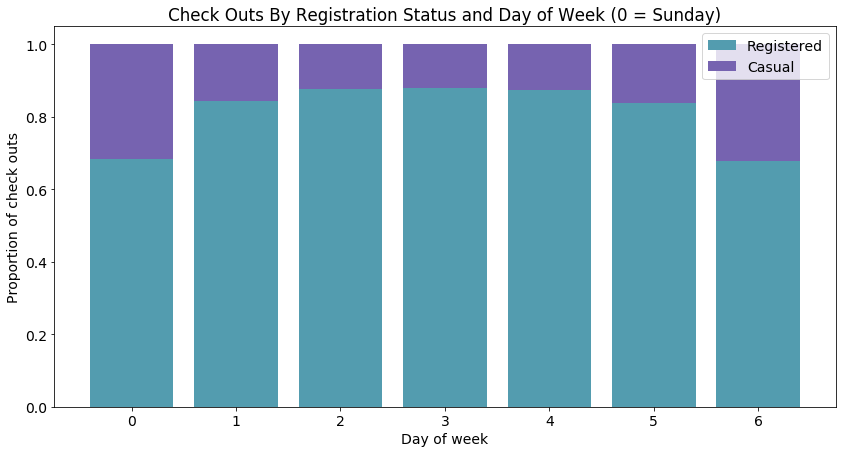

```python
# 绘制堆积柱状图
def stackedbarplot(x_data, y_data_list, y_data_names, colors, x_label, y_label, title):
    _, ax = plt.subplots()
    # 循环绘制堆积柱状图
    for i in range(0, len(y_data_list)):
        if i == 0:
            ax.bar(x_data, y_data_list[i], color = colors[i], align = 'center', label = y_data_names[i])
        else:
            # 采用堆积的方式，除了第一个分类，后面的分类都从前一个分类的柱状图接着画
            # 用归一化保证最终累积结果为1，下面bottom参数表示纵向从哪里开始画
            ax.bar(x_data, y_data_list[i], color = colors[i], bottom = y_data_list[i - 1], align = 'center', label = y_data_names[i])
    ax.set_ylabel(y_label)
    ax.set_xlabel(x_label)
    ax.set_title(title)
    ax.legend(loc = 'upper right') # 设定图例位置

# 调用绘图函数
stackedbarplot(x_data = mean_by_reg_co_day.index.values
               , y_data_list = [mean_by_reg_co_day['reg_prop'], mean_by_reg_co_day['casual_prop']]
               , y_data_names = ['Registered', 'Casual']
               , colors = ['#539caf', '#7663b0']
               , x_label = 'Day of week'
               , y_label = 'Proportion of check outs'
               , title = 'Check Outs By Registration Status and Day of Week (0 = Sunday)')
```

- 从这幅图你看出了什么？工作日 VS 节假日（每天预约和偶然租车的相对量）
- 为什么会有这样的差别？周末的随机性更大。

### 分组柱状图

- 多级类间绝对数值比较

```python
# 绘制分组柱状图的函数
def groupedbarplot(x_data, y_data_list, y_data_names, colors, x_label, y_label, title):
    _, ax = plt.subplots()
    # 设置每一组柱状图的宽度
    total_width = 0.8
    # 设置每一个柱状图的宽度
    ind_width = total_width / len(y_data_list)
    # 计算每一个柱状图的中心偏移
    alteration = np.arange(-total_width/2+ind_width/2, total_width/2+ind_width/2, ind_width)

    # 分别绘制每一个柱状图
    for i in range(0, len(y_data_list)):
        # 横向散开绘制
        ax.bar(x_data + alteration[i], y_data_list[i], color = colors[i], label = y_data_names[i], width = ind_width)
    ax.set_ylabel(y_label)
    ax.set_xlabel(x_label)
    ax.set_title(title)
    ax.legend(loc = 'upper right')
```

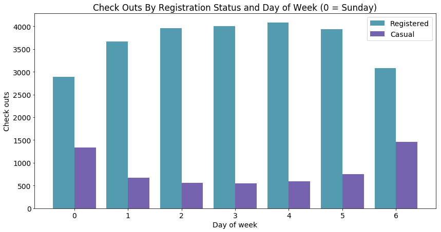

```python
# 调用绘图函数
groupedbarplot(x_data = mean_by_reg_co_day.index.values
               , y_data_list = [mean_by_reg_co_day['registered'], mean_by_reg_co_day['casual']]
               , y_data_names = ['Registered', 'Casual']
               , colors = ['#539caf', '#7663b0']
               , x_label = 'Day of week'
               , y_label = 'Check outs'
               , title = 'Check Outs By Registration Status and Day of Week (0 = Sunday)')
```

- 偏移前：ind_width/2
- 偏移后：total_width/2
- 偏移量：total_width/2-ind_width/2